# Lab 2 - Data Exploration and Analysis

[figure not shown]

[figure not shown]

[figure not shown]

[figure not shown]

[figure not shown]

[figure not shown]

# Page 1

### Chart A: Summary statistics

```
                           dt            AverageTemperature
                            0                         11002
AverageTemperatureUncertainty                          City
                        11002                             0
                      Country                      Latitude
                            0                             0
                    Longitude
                            0
```

```
   Min. 1st Qu.  Median    Mean 3rd Qu.    Max.    NA's
 -26.77   12.71   20.43   18.13   25.92   38.28   11002
```

```
   Min. 1st Qu.  Median    Mean 3rd Qu.    Max.    NA's
  0.040   0.340   0.592   0.969   1.320  14.037   11002
```

### Chart B: Geographical coverage and grouping:group by country or city to see the number of observations per group:

```
# A tibble: 49 × 2
   Country       count
   <chr>         <int>
 1 India         36582
 2 China         35444
 3 Brazil        12930
 4 Turkey         9473
 5 United States  8455
 6 Egypt          7589
 7 Pakistan       7355
 8 Canada         6478
 9 Russia         6478
10 Nigeria        5763
# ℹ 39 more rows
```

# Page 2

### Chart C: Check date range and time granularity

```
[1] "1743-11-01" "2013-09-01"
```

### Chart D: Geographical coverage and grouping: Unique cities and countries

```
[1] 100
```

```
[1] 49
```

# Page 3

### Chart E: Histogram of Average Temperatures

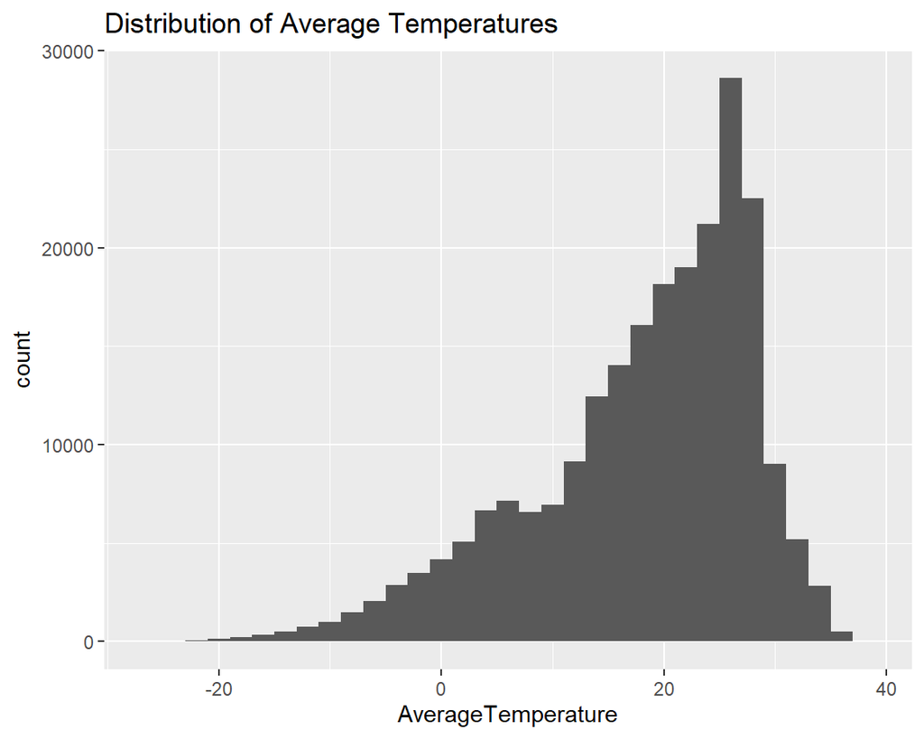

# Page 4

### Chart F: Time Series Plot for a Single City

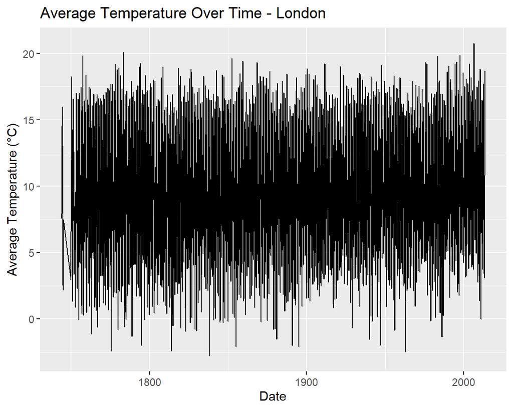

# Page 5

### Chart G: Boxplot by City

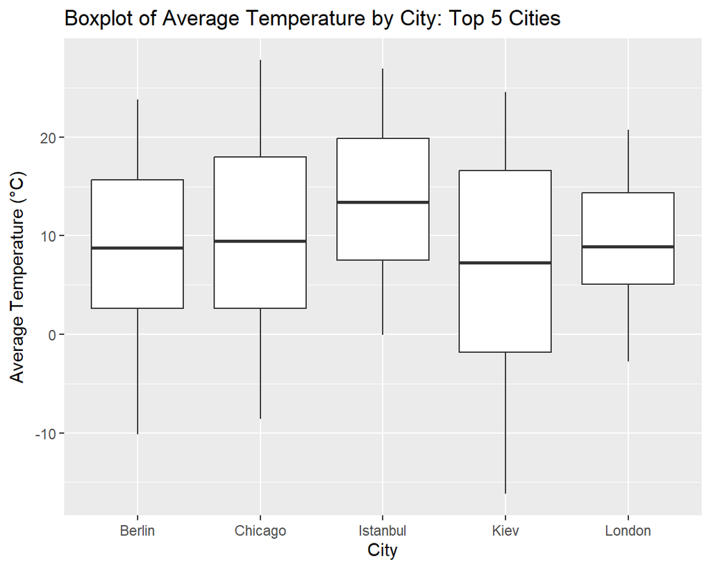

# Page 6

### Chart H: Bar Chart of Mean Temperatures by Country

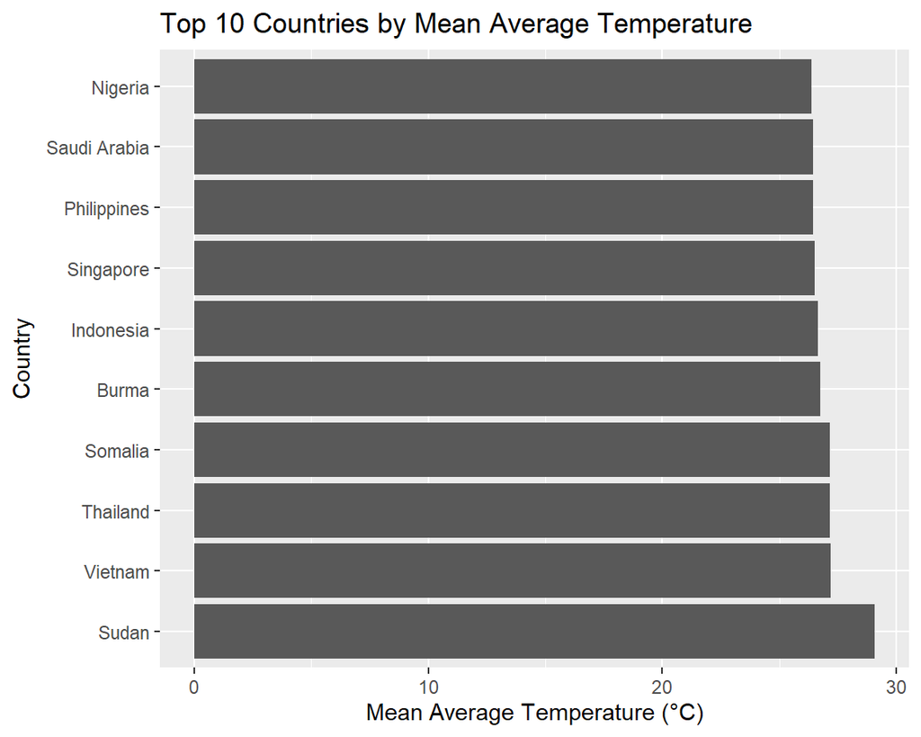

# Page 7

### Chart I: Seasonal Variation: Boxplot by Month

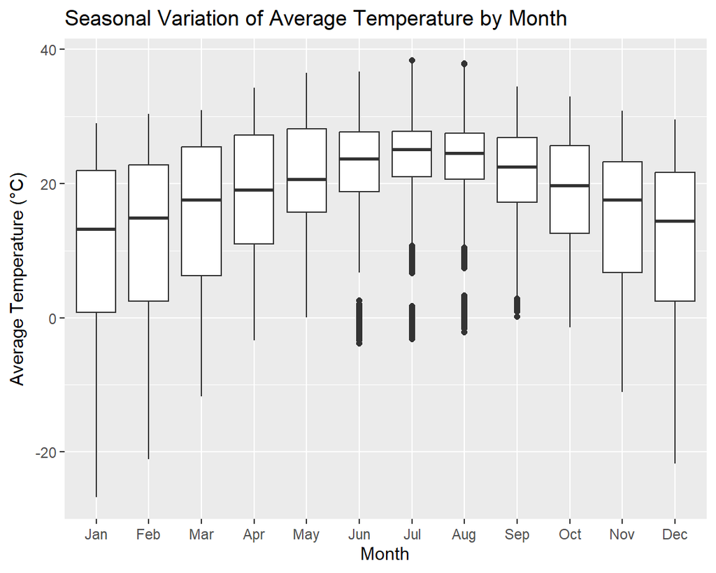

# Page 8

### Chart J: Heatmap of Monthly Averages Over Time

[figure not shown]

# Page 9

### Chart K: Develop four questions or ideas about climate change from your visualizations.

*1. Long-Term Warming Trends in Specific Cities:*

Are certain cities experiencing more pronounced warming trends than others, and which historical periods show the most significant temperature increases?

*2. Shifts in Temperature Distribution Over Time:*

Has the temperature distribution widened over decades, suggesting more extreme heat events or an upward shift in baseline temperatures?

*3. Seasonal Patterns and Changing Extremes:*

Are the differences between summer and winter temperatures changing, and are certain months warming at a faster rate than others, indicating a potential shift in seasonal cycles?

*4. Regional/Latitudinal Contrasts:*

Do lower-latitude (tropical) regions already experiencing higher baseline temperatures face a disproportionate temperature increase over time, or are mid-latitude regions catching up due to accelerated warming trends?

*Dataset name:* Climate Change: Earth Surface Temperature Data

*Link:* https://www.kaggle.com/datasets/berkeleyearth/climate-change-earth-surface-temperature-data